# Predict exercise grades using random forests

## Reading the data

Initially, the training data is loaded into R. The read.csv function is used to load the training data into a data frame.

Using the caret, the training dataset is then split into a training and test dataset using the createDataPartition function. The data is randomly sampled with 60% of the data belonging to the training dataset.

## Cleaning the data

Looking at the columns in the training data set, it is noticible that many of the features have a large number of ‘NA’ fields. In order to build a model, all the features with large proportion of NA values are removed. Any feature more than 95% NA values are eliminated from the dataset.

After removing the features with a high proportion of NAs, it is noticible that several of the remaining coloumns have a large number of blank entries. In order to check if these are useful, we use the nearZeroVar function to evaluate the variance of the features. A few of the features have near zero variance. These are also eliminated from the training data.

Finally, the first few columns of the dataset contain row numbers, user names and time related information. These features are not useful in building a predictive model and are eliminated from the datatset.

As a result, we are left with a training dataset of 53 features. The same transformations are also applied to the testing subset of train dataset.

## Pre-processing the training data

In order to explore the features in the training data set, we perform a random forest cross-validation to get an estimate of the number of features that would be required in building a model. The random forest cross validation is performed using 5 folds and 70% of the features are retainded after every attempt.

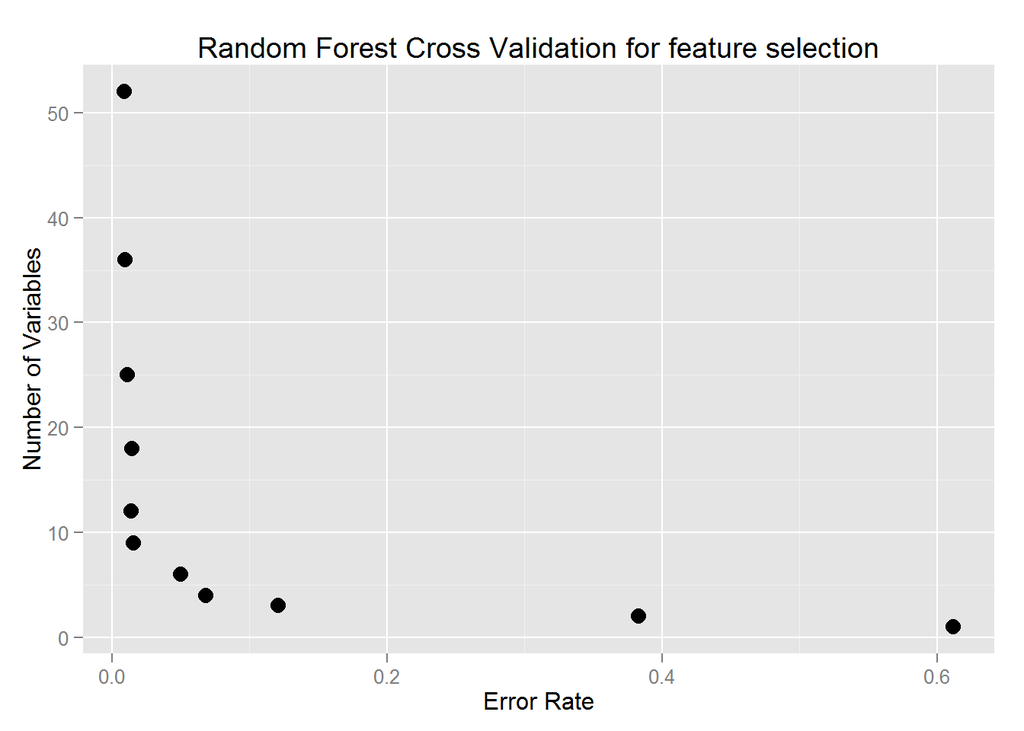

The figure above shows how the error rate increases as number of variables are reducded. The error rate doesn’t go significantly above zero until the number of features is less than 10. Therefore, it is clear that we don’t need to use all the 52 features to build the model.

Now, we use principle componenet analysis to shrink the feature space. The first step in pre-processing involves running a priciple component analysis and generating only 2 principle components.

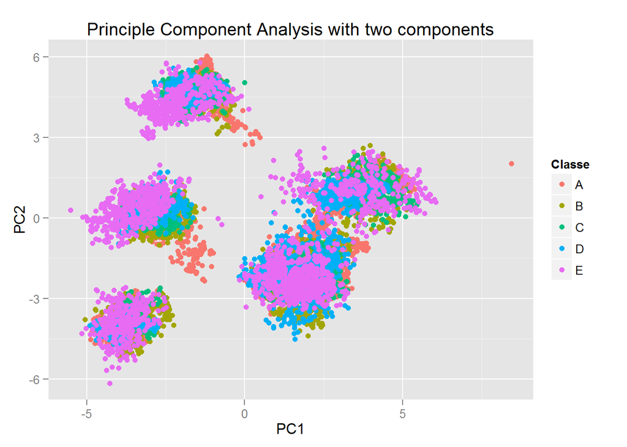

For the final model, we run principle component analysis on the training data with a threshold of 90%.

A total of 18 components are required to capture 90% variance from all the features. From the preprocessed object, a new set of features are created for the training dataset.

## Prediction Model & Analysis

To build a prediction model, we use the random forest algorithm. In order to perform re-sampling, a bootstrap is used with replacement. Bootstrapping is performed 25 times to obtain the optimum prediction. To enable faster processing, the doParallel package is used.

In order to estimate the insample error rate, the model is used to predict the training data.

```r
cf.train <- confusionMatrix(predict(rf.fit,trainPC.final), pml.train.subset$classe)
cf.train$overall["Accuracy"]
```

```
## Accuracy
##        1
```

Therefore, we observe that the model has 100% accuracy on the training data set.

The plot below shows the how each principle component impacts the GINI Index error rate. Clearly, all of the priniciple components contribute to the reduction in Gini index.

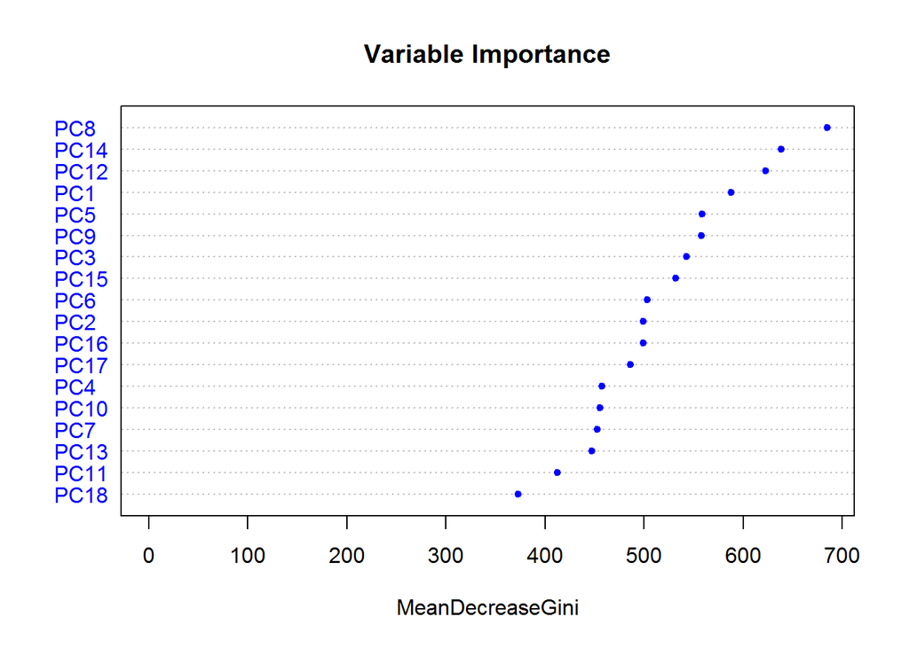

## Out of Sample Error

In order to estimate the out of sample error rate, the model is used to predict the testing data that was obtained by splitting the original training dataset. To obtain the principle components for the testng data, the preprocess object from the training data is used.

```
##       Accuracy          Kappa  AccuracyLower  AccuracyUpper   AccuracyNull
##      9.662e-01      9.573e-01      9.620e-01      9.701e-01      2.845e-01
## AccuracyPValue  McnemarPValue
##      0.000e+00      4.840e-08
```

Using confusion matrix, we see that an accuracy of 0.9662 is obtained. This implies that the out of sample error rate is 0.0338.